# ENV 790.30 - Time Series Analysis for Energy Data | Spring 2023

Assignment 5 - Due date 02/27/23

## Directions

You should open the .rmd file corresponding to this assignment on RStudio. The file is available on our class repository on Github. And to do so you will need to fork our repository and link it to your RStudio.

Once you have the file open on your local machine the first thing you will do is rename the file such that it includes your first and last name (e.g., “LuanaLima_TSA_A05_Sp23.Rmd”). Then change “Student Name” on line 4 with your name.

Then you will start working through the assignment by **creating code and output** that answer each question. Be sure to use this assignment document. Your report should contain the answer to each question and any plots/tables you obtained (when applicable).

When you have completed the assignment, **Knit** the text and code into a single PDF file. Submit this pdf using Sakai.

R packages needed for this assignment: “xlsx” or “readxl”, “ggplot2”, “forecast”,“tseries”, and “Kendall”. Install these packages, if you haven’t done yet. Do not forget to load them before running your script, since they are NOT default packages.\

```r
#Load/install required package here
library(xlsx)
library(forecast)
```

```r
library(tseries)
library(ggplot2)
library(Kendall)
library(lubridate)
library(dplyr)
library(tidyverse)  #load this package so yon clean the data frame using pipes
library(naniar)
library(tidyr)
```

## Decomposing Time Series

Consider the same data you used for A04 from the spreadsheet “Table_10.1_Renewable_Energy_Production_and_Consumption_by_Source.xlsx”.

```r
#Importing data set - using xlsx package
energy_data <- read.xlsx(file="./Data/Table_10.1_Renewable_Energy_Production_and_Consumption_by_Source.xlsx",header=FALSE,startRow = 13,sheetIndex=1) #startRow is equivalent to skip on read.table

#Now let's extract the column names from row 11 only
read_col_names <- read.xlsx(file="./Data/Table_10.1_Renewable_Energy_Production_and_Consumption_by_Source.xlsx",header=FALSE,startRow = 11,endRow=11,sheetIndex=1)

colnames(energy_data) <- read_col_names
head(energy_data)
```

|  | Month | Wood Energy Production | Biofuels Production | Total Biomass Energy Production | Total Renewable Energy Production | Hydroelectric Power Consumption | Geothermal Energy Consumption | Solar Energy Consumption | Wind Energy Consumption | Wood Energy Consumption | Waste Energy Consumption | Biofuels Consumption | Total Biomass Energy Consumption | Total Renewable Energy Consumption |
| --- | --- | --- | --- | --- | --- | --- | --- | --- | --- | --- | --- | --- | --- | --- |
| 1 | 1973-01-01 | 129.630 | Not Available | 129.787 | 403.981 | 272.703 | 1.491 | Not Available | Not Available | 129.630 | 0.157 | Not Available | 129.787 | 403.981 |
| 2 | 1973-02-01 | 117.194 | Not Available | 117.338 | 360.900 | 242.199 | 1.363 | Not Available | Not Available | 117.194 | 0.144 | Not Available | 117.338 | 360.900 |
| 3 | 1973-03-01 | 129.763 | Not Available | 129.938 | 400.161 | 268.810 | 1.412 | Not Available | Not Available | 129.763 | 0.176 | Not Available | 129.938 | 400.161 |
| 4 | 1973-04-01 | 125.462 | Not Available | 125.636 | 380.470 | 253.185 | 1.649 | Not Available | Not Available | 125.462 | 0.174 | Not Available | 125.636 | 380.470 |
| 5 | 1973-05-01 | 129.624 | Not Available | 129.834 | 392.141 | 260.770 | 1.537 | Not Available | Not Available | 129.624 | 0.210 | Not Available | 129.834 | 392.141 |
| 6 | 1973-06-01 | 125.435 | Not Available | 125.611 | 377.232 | 249.859 | 1.763 | Not Available | Not Available | 125.435 | 0.176 | Not Available | 125.611 | 377.232 |

```r
nobs=nrow(energy_data)
nvar=ncol(energy_data)
```

### Q1

For this assignment you will work only with the following columns: Solar Energy Consumption and Wind Energy Consumption. Create a data frame structure with these two time series only and the Date column. Drop the rows with *Not Available* and convert the columns to numeric. You can use filtering to eliminate the initial rows or convert to numeric and then use the drop_na() function. If you are familiar with pipes for data wrangling, try using it!

```r
# Filter out the columns we need
energy_subset <- energy_data %>%
select(`Month`, `Solar Energy Consumption`, `Wind Energy Consumption`)

energy_subset <- drop_na(energy_subset, c("Solar Energy Consumption", "Wind Energy Consumption"))

energy_subset$`Solar Energy Consumption` <- as.numeric(energy_subset$`Solar Energy Consumption`)
energy_subset$`Wind Energy Consumption` <- as.numeric(energy_subset$`Wind Energy Consumption`)
```

### Q2

Plot the Solar and Wind energy consumption over time using ggplot. Plot each series on a separate graph. No need to add legend. Add informative names to the y axis using `ylab()`. Explore the function scale_x_date() on ggplot and see if you can change the x axis to improve your plot. Hint: use *scale_x_date(date_breaks = “5 years”, date_labels = “%Y”)“)*

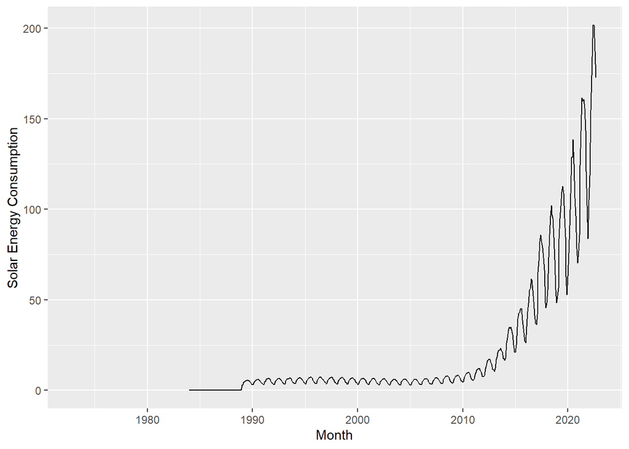

```r
ggplot(energy_subset, aes(x = Month, y = `Solar Energy Consumption`)) +
geom_line() +
ylab("Solar Energy Consumption")
```

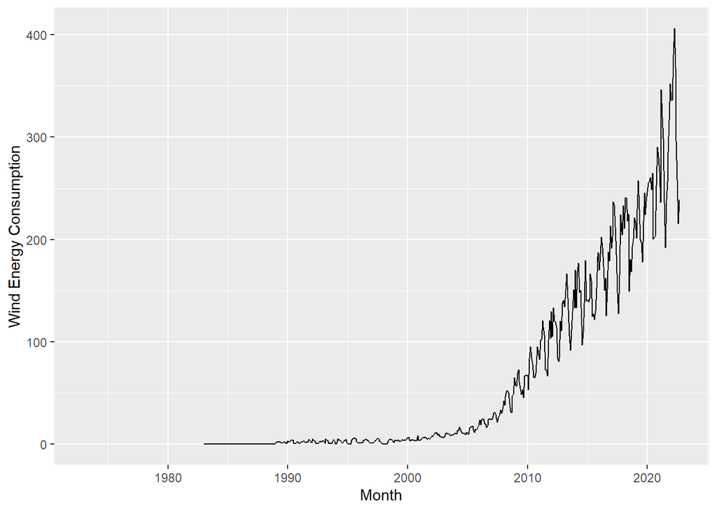

```r
# plot wind energy consumption over time
ggplot(energy_subset, aes(x = Month, y = `Wind Energy Consumption`)) +
geom_line() +
ylab("Wind Energy Consumption")
```

### Q3

Now plot both series in the same graph, also using ggplot(). Look at lines 141-148 of the file `M4_OutliersMissingData_Part2_Complete.Rmd` to learn how to manually add a legend to ggplot. Make the solar energy consumption red and wind energy consumption blue. Add informative name to the y axis using `ylab("Energy Consumption)`. And use function scale_x_date() again to improve x axis.

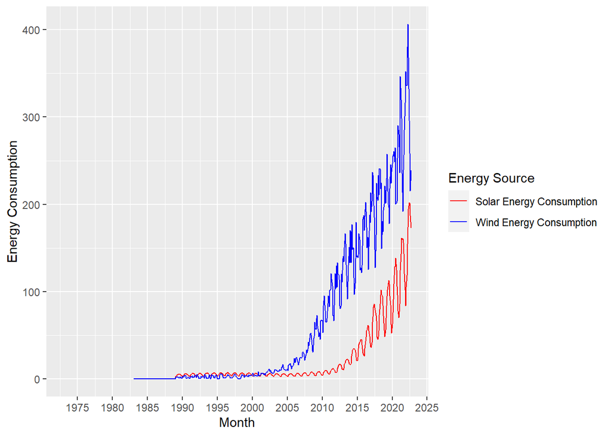

```r
ggplot(energy_subset, aes(x = Month)) +
geom_line(aes(y = `Solar Energy Consumption`, color = "Solar Energy Consumption")) +
geom_line(aes(y = `Wind Energy Consumption`, color = "Wind Energy Consumption")) +
ylab("Energy Consumption") +
scale_x_date(date_breaks = "5 years", date_labels = "%Y") +
scale_color_manual(values = c("red", "blue"),
name = "Energy Source",
labels = c("Solar Energy Consumption", "Wind Energy Consumption"))
```

### Q3

Transform wind and solar series into a time series object and apply the decompose function on them using the additive option, i.e., `decompose(ts_data, type = "additive")`. What can you say about the trend component? What about the random component? Does the random component look random? Or does it appear to still have some seasonality on it?

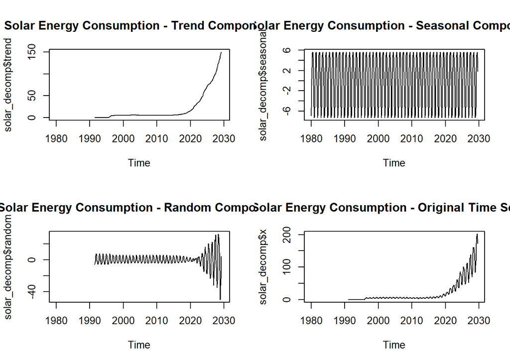

```r
# Convert the Solar Energy Consumption and Wind Energy Consumption columns into time series objects
solar_ts <- ts(energy_subset$`Solar Energy Consumption`, frequency = 12, start = c(1980, 1))
wind_ts <- ts(energy_subset$`Wind Energy Consumption`, frequency = 12, start = c(1980, 1))
# Apply the decompose function on both time series using the additive option
solar_decomp <- decompose(solar_ts, type = "additive")
wind_decomp <- decompose(wind_ts, type = "additive")
# Plot the decomposed components for Solar Energy Consumption
par(mfrow = c(2, 2))
plot(solar_decomp$trend, main = "Solar Energy Consumption - Trend Component")
plot(solar_decomp$seasonal, main = "Solar Energy Consumption - Seasonal Component")
plot(solar_decomp$random, main = "Solar Energy Consumption - Random Component")
plot(solar_decomp$x, main = "Solar Energy Consumption - Original Time Series")
```

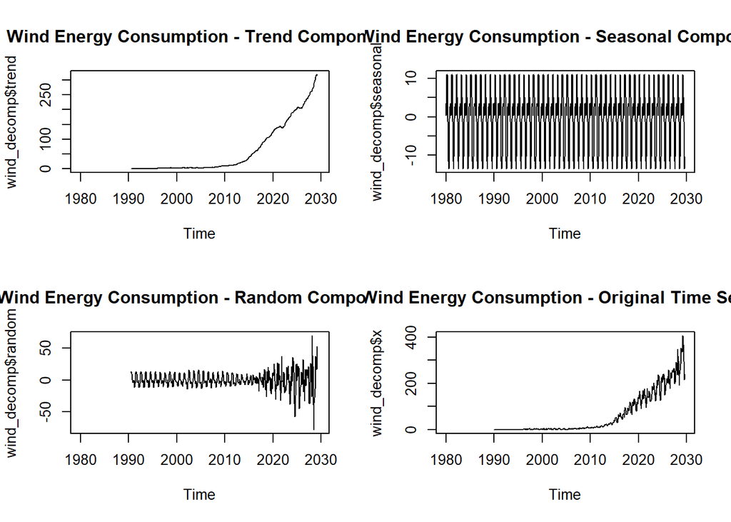

```r
# Plot the decomposed components for Wind Energy Consumption
par(mfrow = c(2, 2))
plot(wind_decomp$trend, main = "Wind Energy Consumption - Trend Component")
plot(wind_decomp$seasonal, main = "Wind Energy Consumption - Seasonal Component")
plot(wind_decomp$random, main = "Wind Energy Consumption - Random Component")
plot(wind_decomp$x, main = "Wind Energy Consumption - Original Time Series")
```

There are overall increasing trend for both, and there are fluctuations in seasons across the year. We could have other factors affecting the energy consumption.

### Q4

Use the decompose function again but now change the type of the seasonal component from additive to multiplicative. What happened to the random component this time?

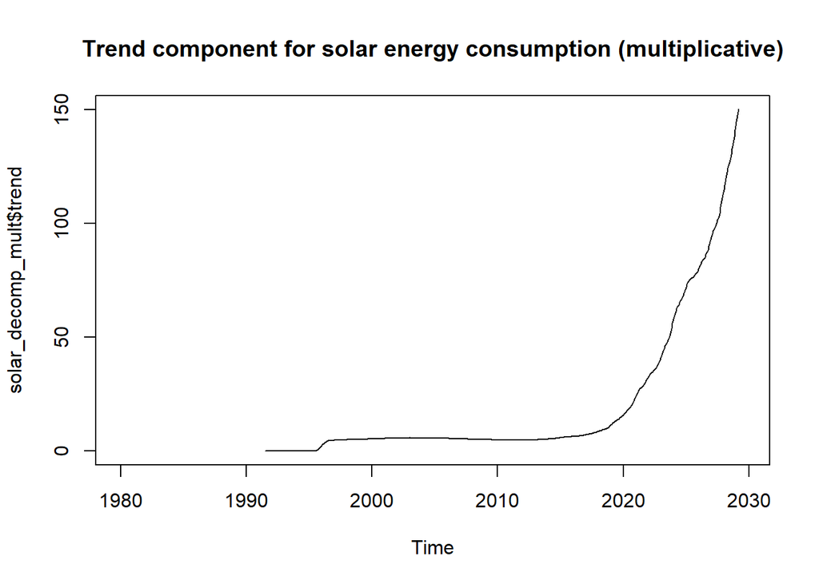

```r
# Decompose both time series using the multiplicative option
solar_decomp_mult <- decompose(solar_ts, type = "multiplicative")
wind_decomp_mult <- decompose(wind_ts, type = "multiplicative")
# Look at the trend and random components for the solar series
plot(solar_decomp_mult$trend, main = "Trend component for solar energy consumption (multiplicative)")
```

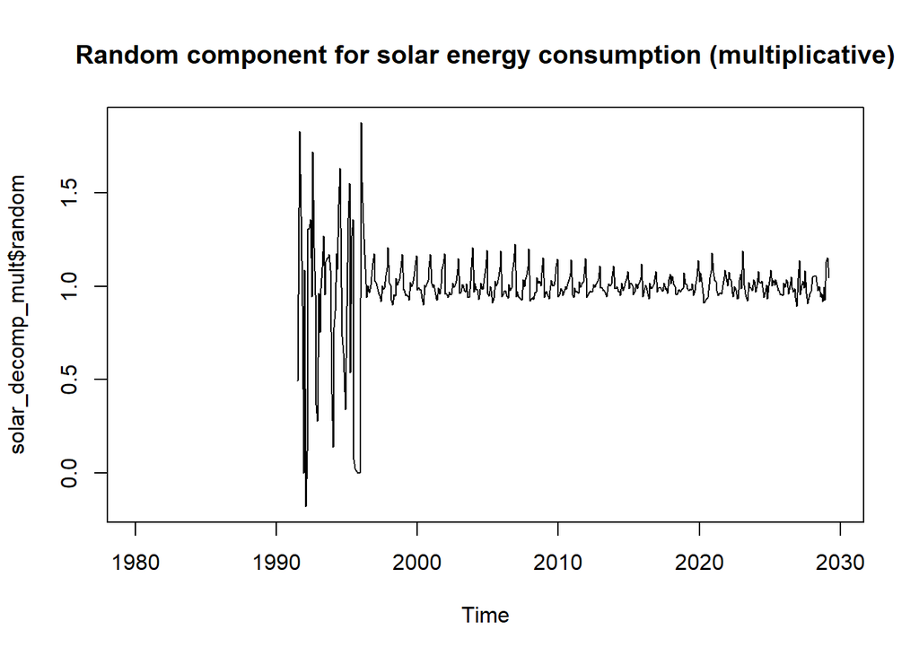

```r
plot(solar_decomp_mult$random, main = "Random component for solar energy consumption (multiplicative)")
```

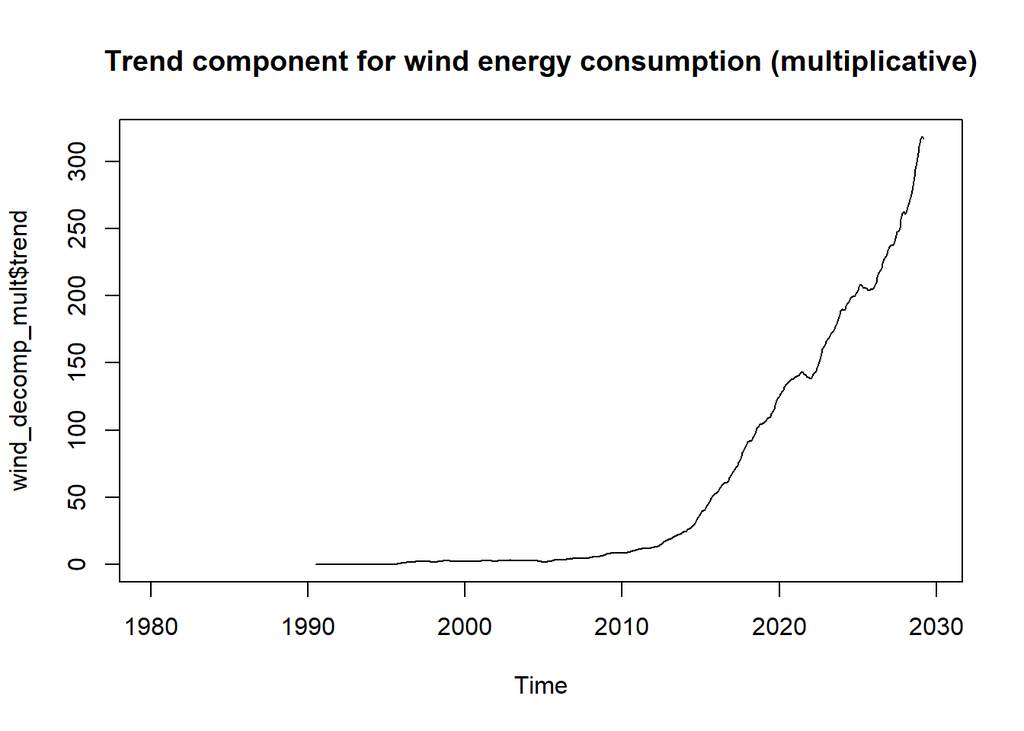

```r
# Look at the trend and random components for the wind series
plot(wind_decomp_mult$trend, main = "Trend component for wind energy consumption (multiplicative)")
```

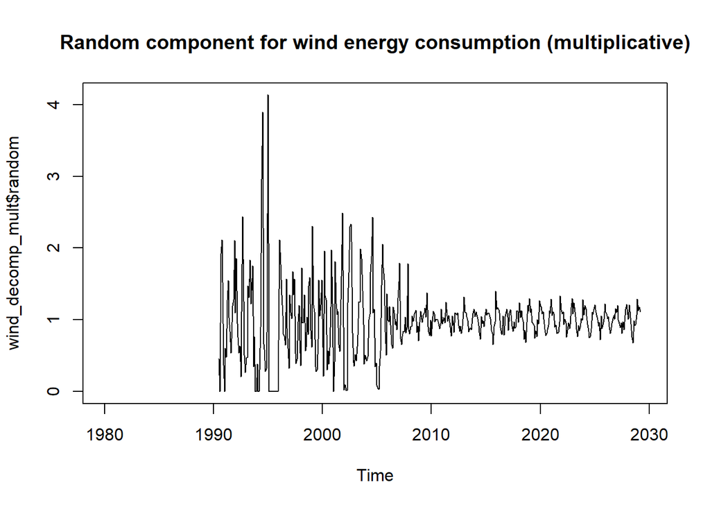

```r
plot(wind_decomp_mult$random, main = "Random component for wind energy consumption (multiplicative)")
```

### Q5

When fitting a model to this data, do you think you need all the historical data? Think about the data from 90s and early 20s. Are there any information from those years we might need to forecast the next six months of Solar and/or Wind consumption. Explain your response.

> Answer:historical data provides additional accuracy that the model may compared to, and the recent data reveals the most current pattern of energy consumption.

### Q6

Create a new time series object where historical data starts on January 2012. Hint: use `filter()` function so that you don’t need to point to row numbers, .i.e, `filter(xxxx, year(Date) >= 2012 )`. Apply the decompose function `type=additive` to this new time series. Comment the results. Does the random component look random? Think about our discussion in class about seasonal components that depends on the level of the series.

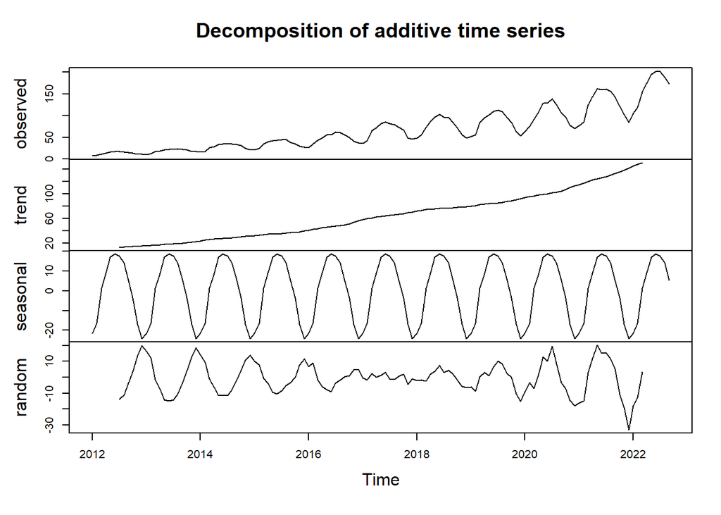

```r
# filter out data from January 2012 onwards
energy_subset_new <- energy_subset %>%
filter(year(Month) >= 2012)
# create time series objects for solar and wind energy consumption
solar_ts <- ts(energy_subset_new$`Solar Energy Consumption`, frequency = 12, start = c(2012, 1))
wind_ts <- ts(energy_subset_new$`Wind Energy Consumption`, frequency = 12, start = c(2012, 1))
# decompose both time series using additive method
solar_decomp <- decompose(solar_ts, type = "additive")
wind_decomp <- decompose(wind_ts, type = "additive")
# plot the decomposed components of solar energy consumption
plot(solar_decomp)
```